# Proyecto Exploración de Datos

Profesor: Ronald Córdoba Vega - BD-142

Sebastián Calvo - Daniel Nájera - Eduardo Núñez - Mauricio Ortiz - Josué Redondo

2026-04-05

- DESCRIPCIÓN
- LECTURA
- LIMPIEZA
- EDA
- CLUSTER

# DESCRIPCIÓN DEL DATASET

Dataset

FIFA Player Performance & Market Value Dataset.

Este es el dataset con el que vamos a realizar el proyecto y tal y como su nombre lo indica este dataset recopila y analiza las actuaciones de jugadores de futbol profesionales, además de los atributos de sus habilidades y el valor en el mercado gracias a su desempeño en el videojuego FIFA.

Descripción de Columnas

Con 2800 datos registrados el dataset cuenta con distintas columnas como lo son:

1. player_id: Esto es un identificador único para cada jugador, evitando así confusión de a que jugador pertenece la información almacenada.
2. player_name: El nombre que el jugador tiene.
3. age: La edad que posee el jugador para el momento en el que se registraron los datos.
4. nationality: Es el país donde pertenece el jugador
5. club: Equipo donde el jugador juega durante el registro de datos.
6. postion: Es la posición en la cual el jugador desempeña su rol durante el partido.
7. overall_rating: Es la clasificación promedio que recibió el jugador por su desempeño durante los partidos.
8. potential_ratings: Es el potencial máximo que esperaban para dicho jugador.
9. matches_played: Cantidad total de partidos que jugó.
10. goals: Goles anotados en todos los partidos disputados.
11. assist: Asistencias realizadas en durante todos los partidos.
12. minutes_played: Cantidad total de minutos jugados.
13. market_value_million_eur: Precio del jugador en el mercado europeo, y su valor representado en millones de euros (1 = un millón)
14. contract_years_left: Cantidad de tiempo que posee el contrato antes de acabarse.
15. injury_prone: Esto hace referencia a si el jugador es susceptible a lesionarse frecuentemente.
16. transfer_risk_level: Esto dice si la posibilidad de ser transferido a otro culb es alta, media o baja.

# LECTURA DE DATOS

Carga de Datos

En este apartado veremos los datos en CRUDO del dataset para ver la información que posee, el tipo de datos que es y si se debe o no realizar una limpieza de datos.

```r
datos <- read.csv('fifa_player_performance_market_value.csv')
```

Función Head

Se realiza un head para verificar que la información se cargó correctamente mediante la función head, esta función nos muestra los primeros datos que hay dentro del dataset

```r
head(datos)
```

```
##   player_id player_name age nationality            club position overall_rating
## 1         1    Player_1  23     Germany       Liverpool       ST             65
## 2         2    Player_2  36     England    FC Barcelona       ST             90
## 3         3    Player_3  31      France        Juventus       RB             75
## 4         4    Player_4  27    Portugal Manchester City       LW             90
## 5         5    Player_5  24      Brazil       Liverpool      CDM             84
## 6         6    Player_6  37   Argentina Manchester City       CM             92
##   potential_rating matches_played goals assists minutes_played
## 1               87              8     6      14           2976
## 2               76             19     3      18           2609
## 3               91             34    12      15           1158
## 4               86             35    18      13            145
## 5               96             41     6       6           2226
## 6               91             35     9       7            263
##   market_value_million_eur contract_years_left injury_prone transfer_risk_level
## 1                   122.51                   3           No                 Low
## 2                    88.47                   5           No                High
## 3                    20.24                   3           No              Medium
## 4                   164.29                   0          Yes              Medium
## 5                   121.34                   4           No                 Low
## 6                    98.51                   5          Yes                 Low
```

Función Tail

Se realiza un tail para terminar de comprobar que los datos se cargaron de manera correcta y que no hubo ningun fallo en el proceso, tail muestra los últimos registros del datset.

```r
tail(datos)
```

```
##      player_id player_name age nationality            club position
## 2795      2795 Player_2795  36   Argentina             PSG       RW
## 2796      2796 Player_2796  32     Germany   Bayern Munich       CB
## 2797      2797 Player_2797  31 Netherlands     Real Madrid       LB
## 2798      2798 Player_2798  31      Brazil Manchester City       ST
## 2799      2799 Player_2799  22 Netherlands     Real Madrid       ST
## 2800      2800 Player_2800  31     Germany       Liverpool      CDM
##      overall_rating potential_rating matches_played goals assists
## 2795             67               93             11    38      11
## 2796             67               65             47    10      12
## 2797             67               85              5     7       1
## 2798             93               88              8    36       8
## 2799             75               73             34     7       6
## 2800             72               90              7    11      12
##      minutes_played market_value_million_eur contract_years_left injury_prone
## 2795           2470                    92.54                   3           No
## 2796           4067                    99.49                   3           No
## 2797           3460                    74.87                   4           No
## 2798           3768                    27.01                   3           No
## 2799           1934                    54.95                   4           No
## 2800           2319                    44.83                   5          Yes
##      transfer_risk_level
## 2795                 Low
## 2796              Medium
## 2797                 Low
## 2798              Medium
## 2799              Medium
## 2800                 Low
```

En este caso se visualizan los datos de manera completa y coherente.

Función STR

Revisamos qué tipo es cada columna antes de operar con ellas, esto mediante la función str que nos da la información de cada columna.

```r
str(datos)
```

```
## 'data.frame':    2800 obs. of  16 variables:
##  $ player_id               : int  1 2 3 4 5 6 7 8 9 10 ...
##  $ player_name             : chr  "Player_1" "Player_2" "Player_3" "Player_4" ...
##  $ age                     : int  23 36 31 27 24 37 23 35 39 27 ...
##  $ nationality             : chr  "Germany" "England" "France" "Portugal" ...
##  $ club                    : chr  "Liverpool" "FC Barcelona" "Juventus" "Manchester City" ...
##  $ position                : chr  "ST" "ST" "RB" "LW" ...
##  $ overall_rating          : int  65 90 75 90 84 92 72 69 83 69 ...
##  $ potential_rating        : int  87 76 91 86 96 91 66 97 90 92 ...
##  $ matches_played          : int  8 19 34 35 41 35 53 8 21 0 ...
##  $ goals                   : int  6 3 12 18 6 9 24 34 24 28 ...
##  $ assists                 : int  14 18 15 13 6 7 6 17 23 5 ...
##  $ minutes_played          : int  2976 2609 1158 145 2226 263 4299 3101 2106 3080 ...
##  $ market_value_million_eur: num  122.5 88.5 20.2 164.3 121.3 ...
##  $ contract_years_left     : int  3 5 3 0 4 5 1 0 3 1 ...
##  $ injury_prone            : chr  "No" "No" "No" "Yes" ...
##  $ transfer_risk_level     : chr  "Low" "High" "Medium" "Medium" ...
```

Función Sapply

La función sapply lo que realiza es darnos una matriz con la información de los elementos que le digamos, en este caso le indicamos las clases y verificamos que numéricas, enteros y caracteres estén bien clasificados.

```r
sapply(datos, class)
```

```
##                player_id              player_name                      age
##                "integer"              "character"                "integer"
##              nationality                     club                 position
##              "character"              "character"              "character"
##           overall_rating         potential_rating           matches_played
##                "integer"                "integer"                "integer"
##                    goals                  assists           minutes_played
##                "integer"                "integer"                "integer"
## market_value_million_eur      contract_years_left             injury_prone
##                "numeric"                "integer"              "character"
##      transfer_risk_level
##              "character"
```

Función colSums

Antes de continuar con el análisis, revisamos si hay valores nulos en el dataset.

Para esto utilizaremos la función colSums la cual realiza una suma de todos los elementos encontrados en las columnas, en este caso le indicamos que si la columna posee un nulo (as.null) esta la vaya sumando.

```r
colSums(is.na(datos))
```

```
##                player_id              player_name                      age
##                        0                        0                        0
##              nationality                     club                 position
##                        0                        0                        0
##           overall_rating         potential_rating           matches_played
##                        0                        0                        0
##                    goals                  assists           minutes_played
##                        0                        0                        0
## market_value_million_eur      contract_years_left             injury_prone
##                        0                        0                        0
##      transfer_risk_level
##                        0
```

Afortunadamente, no encontramos ninguno, así que podemos avanzar sin preocupaciones.

Se verifica si exiten posibles datos duplicados que puedan afectar el analisis.

```r
anyDuplicated(datos)
```

```
## [1] 0
```

En este caso no existen.

Función Summary

Por último en el apartado de la lectura de datos poseemos la función summary, esta función es una muy importante en esta etapa ya que de manera similar a la función str esta nos da información de los elementos de la columna, pero, no se resume en eso sino que además nos brinda elementos como la media de los elementos almacenados, el mínimo, el máximo e inclusive información sobre los cuartiles que esta posee.

Esto convierte a summary en un elemento clave a la hora de la visualización de datos.

```r
summary(datos)
```

```
##    player_id      player_name             age        nationality
##  Min.   :   1.0   Length:2800        Min.   :17.00   Length:2800
##  1st Qu.: 700.8   Class :character   1st Qu.:22.00   Class :character
##  Median :1400.5   Mode  :character   Median :28.00   Mode  :character
##  Mean   :1400.5                      Mean   :27.95
##  3rd Qu.:2100.2                      3rd Qu.:34.00
##  Max.   :2800.0                      Max.   :39.00
##      club             position         overall_rating  potential_rating
##  Length:2800        Length:2800        Min.   :60.00   Min.   :65.00
##  Class :character   Class :character   1st Qu.:68.00   1st Qu.:73.00
##  Mode  :character   Mode  :character   Median :77.00   Median :82.00
##                                        Mean   :76.87   Mean   :81.56
##                                        3rd Qu.:85.00   3rd Qu.:90.00
##                                        Max.   :94.00   Max.   :98.00
##  matches_played      goals          assists      minutes_played
##  Min.   : 0.00   Min.   : 0.00   Min.   : 0.00   Min.   :   0
##  1st Qu.:13.75   1st Qu.: 9.00   1st Qu.: 6.00   1st Qu.:1131
##  Median :27.00   Median :19.00   Median :12.00   Median :2251
##  Mean   :27.14   Mean   :19.26   Mean   :12.02   Mean   :2250
##  3rd Qu.:41.00   3rd Qu.:30.00   3rd Qu.:18.00   3rd Qu.:3366
##  Max.   :54.00   Max.   :39.00   Max.   :24.00   Max.   :4497
##  market_value_million_eur contract_years_left injury_prone
##  Min.   :  0.67           Min.   :0.000       Length:2800
##  1st Qu.: 45.35           1st Qu.:1.000       Class :character
##  Median : 89.17           Median :3.000       Mode  :character
##  Mean   : 90.57           Mean   :2.528
##  3rd Qu.:136.68           3rd Qu.:4.000
##  Max.   :179.96           Max.   :5.000
##  transfer_risk_level
##  Length:2800
##  Class :character
##  Mode  :character
##
##
##
```

Conclusión de la Lectura

En cancha, el aporte es bastante balanceado: unos 27 partidos jugados, con 19 goles y 12 asistencias en promedio. Eso sí, hay desde suplentes sin minutos hasta figuras que juegan más de 4,000 minutos por temporada.

El mercado muestra una gran desigualdad: mientras algunos apenas superan el millón de euros, otros alcanzan valores cercanos a los 180 millones, dejando claro quiénes son las estrellas

Finalmente, los contratos suelen tener entre 2 y 3 años restantes, lo que obliga a los clubes a decidir pronto si renuevan, venden o arriesgan perder a sus jugadores gratis.

# LIMPIEZA DE DATOS

Limpieza de datos general

En este apartado se va a mostrar el procedimiento realizado para limpiar y estadarizar el dataset, esto permitiendo la búsqueda de obtención de resultados acordes a lo esperado evitando molestias como datos duplicados, errores con los nombres entre otros

Carga del dataset

```r
df_crudo <- read.csv('fifa_player_performance_market_value.csv')
```

Carga de Librerías

```r
library(dplyr)
library(tidyr)
```

Inspección inicial Se visualiza la estructura del dataset por medio de una función propia de dyplr llamada “glimpse” Esta funciona es una alternativa a str que hemos visto en clase para comprender la estructura del dataset

```r
glimpse(datos)
```

```
## Rows: 2,800
## Columns: 16
## $ player_id                <int> 1, 2, 3, 4, 5, 6, 7, 8, 9, 10, 11, 12, 13, 14…
## $ player_name              <chr> "Player_1", "Player_2", "Player_3", "Player_4…
## $ age                      <int> 23, 36, 31, 27, 24, 37, 23, 35, 39, 27, 27, 3…
## $ nationality              <chr> "Germany", "England", "France", "Portugal", "…
## $ club                     <chr> "Liverpool", "FC Barcelona", "Juventus", "Man…
## $ position                 <chr> "ST", "ST", "RB", "LW", "CDM", "CM", "RB", "L…
## $ overall_rating           <int> 65, 90, 75, 90, 84, 92, 72, 69, 83, 69, 90, 7…
## $ potential_rating         <int> 87, 76, 91, 86, 96, 91, 66, 97, 90, 92, 83, 6…
## $ matches_played           <int> 8, 19, 34, 35, 41, 35, 53, 8, 21, 0, 4, 8, 36…
## $ goals                    <int> 6, 3, 12, 18, 6, 9, 24, 34, 24, 28, 11, 39, 1…
## $ assists                  <int> 14, 18, 15, 13, 6, 7, 6, 17, 23, 5, 18, 3, 22…
## $ minutes_played           <int> 2976, 2609, 1158, 145, 2226, 263, 4299, 3101,…
## $ market_value_million_eur <dbl> 122.51, 88.47, 20.24, 164.29, 121.34, 98.51, …
## $ contract_years_left      <int> 3, 5, 3, 0, 4, 5, 1, 0, 3, 1, 0, 2, 5, 5, 3, …
## $ injury_prone             <chr> "No", "No", "No", "Yes", "No", "Yes", "No", "…
## $ transfer_risk_level      <chr> "Low", "High", "Medium", "Medium", "Low", "Lo…
```

Limpieza y Transformación de Datos con dplyr

```r
df_limpio <- df_crudo %>%
  # Elimina filas duplicadas basadas en el ID del jugador, usamos keep_all para tener todos los demas registros
  distinct(player_id, .keep_all = TRUE) %>%

  # Manejo de valores null o NA (faltantes)
  # En este caso, eliminamos filas donde falten datos críticos como el nombre, club o en efecto el valor de mercado
  drop_na(player_name, club, market_value_million_eur) %>%

  # En este otro reemplazamos los NAs que se encuentran columnas numéricas por la mediana o un valor fijo (0)
  mutate(
    matches_played = replace_na(matches_played, 0),
    goals = replace_na(goals, 0),
    assists = replace_na(assists, 0)
  ) %>%

  # Estandarización de texto (Convertir a mayúsculas nombres de clubes y países entre otros valores de texto)
  mutate(
    nationality = toupper(nationality),
    club = toupper(club),
    transfer_risk_level = toupper(transfer_risk_level),
    injury_prone = toupper(injury_prone)
  ) %>%

  # Filtrar datos que podrían llegar a considerarse incosistentes, en este caso la edad el jugador que pueda salirse del rango permitido
  filter(age >= 15 & age <= 50)
```

Visualización del dataset limpio

```r
head(df_limpio,15)
```

```
##    player_id player_name age nationality            club position
## 1          1    Player_1  23     GERMANY       LIVERPOOL       ST
## 2          2    Player_2  36     ENGLAND    FC BARCELONA       ST
## 3          3    Player_3  31      FRANCE        JUVENTUS       RB
## 4          4    Player_4  27    PORTUGAL MANCHESTER CITY       LW
## 5          5    Player_5  24      BRAZIL       LIVERPOOL      CDM
## 6          6    Player_6  37   ARGENTINA MANCHESTER CITY       CM
## 7          7    Player_7  23 NETHERLANDS       LIVERPOOL       RB
## 8          8    Player_8  35       SPAIN   BAYERN MUNICH       LW
## 9          9    Player_9  39      BRAZIL    FC BARCELONA       GK
## 10        10   Player_10  27     ENGLAND       LIVERPOOL       LB
## 11        11   Player_11  27       SPAIN   BAYERN MUNICH       LB
## 12        12   Player_12  37   ARGENTINA             PSG       ST
## 13        13   Player_13  20   ARGENTINA   BAYERN MUNICH       LW
## 14        14   Player_14  24      FRANCE     REAL MADRID       CM
```

[output cut: 49 more lines]

```r
tail(df_limpio,15)
```

```
##      player_id player_name age nationality            club position
## 2786      2786 Player_2786  33 NETHERLANDS        JUVENTUS       RW
## 2787      2787 Player_2787  31      BRAZIL    FC BARCELONA       ST
## 2788      2788 Player_2788  27   ARGENTINA     REAL MADRID       CB
## 2789      2789 Player_2789  38   ARGENTINA    FC BARCELONA       ST
## 2790      2790 Player_2790  29   ARGENTINA   BAYERN MUNICH       GK
## 2791      2791 Player_2791  17     ENGLAND             PSG       ST
## 2792      2792 Player_2792  33      FRANCE        JUVENTUS       CB
## 2793      2793 Player_2793  22   ARGENTINA MANCHESTER CITY       ST
## 2794      2794 Player_2794  20    PORTUGAL             PSG       LB
## 2795      2795 Player_2795  36   ARGENTINA             PSG       RW
## 2796      2796 Player_2796  32     GERMANY   BAYERN MUNICH       CB
## 2797      2797 Player_2797  31 NETHERLANDS     REAL MADRID       LB
## 2798      2798 Player_2798  31      BRAZIL MANCHESTER CITY       ST
## 2799      2799 Player_2799  22 NETHERLANDS     REAL MADRID       ST
```

[output cut: 49 more lines]

```r
# 7. Guardar el dataset limpio
# write.csv(df_limpio, "Fifa_players_limpio.csv", row.names = FALSE)
```

# ANÁLISIS EXPLORATORIO DE DATOS (EDA)

Análisis Exploratorio de datos (EDA)

El análisis de datos exploratorio (EDA) tiene por objetivo identificar las principales características de un conjunto de datos mediante un número reducido de gráficos y/o valores.

Carga del dataset

```r
datos <- read.csv('fifa_player_performance_market_value.csv')
```

Visualización inicial

```r
head(datos, 10)
```

```
##    player_id player_name age nationality            club position
## 1          1    Player_1  23     Germany       Liverpool       ST
## 2          2    Player_2  36     England    FC Barcelona       ST
## 3          3    Player_3  31      France        Juventus       RB
## 4          4    Player_4  27    Portugal Manchester City       LW
## 5          5    Player_5  24      Brazil       Liverpool      CDM
## 6          6    Player_6  37   Argentina Manchester City       CM
## 7          7    Player_7  23 Netherlands       Liverpool       RB
## 8          8    Player_8  35       Spain   Bayern Munich       LW
## 9          9    Player_9  39      Brazil    FC Barcelona       GK
## 10        10   Player_10  27     England       Liverpool       LB
##    overall_rating potential_rating matches_played goals assists minutes_played
## 1              65               87              8     6      14           2976
## 2              90               76             19     3      18           2609
## 3              75               91             34    12      15           1158
```

[output cut: 29 more lines]

```r
tail(datos, 10)
```

```
##      player_id player_name age nationality            club position
## 2791      2791 Player_2791  17     England             PSG       ST
## 2792      2792 Player_2792  33      France        Juventus       CB
## 2793      2793 Player_2793  22   Argentina Manchester City       ST
## 2794      2794 Player_2794  20    Portugal             PSG       LB
## 2795      2795 Player_2795  36   Argentina             PSG       RW
## 2796      2796 Player_2796  32     Germany   Bayern Munich       CB
## 2797      2797 Player_2797  31 Netherlands     Real Madrid       LB
## 2798      2798 Player_2798  31      Brazil Manchester City       ST
## 2799      2799 Player_2799  22 Netherlands     Real Madrid       ST
## 2800      2800 Player_2800  31     Germany       Liverpool      CDM
##      overall_rating potential_rating matches_played goals assists
## 2791             89               72             38    39       3
## 2792             69               86              6     4       2
## 2793             85               89              3    27       3
```

[output cut: 29 more lines]

Carga de Librerías

```r
suppressWarnings(library(dplyr))
suppressWarnings(library(tidyr))
suppressWarnings(library(skimr))
suppressWarnings(library(tibble))
suppressWarnings(library(ggplot2))
```

Inspección inicial

Se visualiza la estructura del dataset por medio de una función propia de dyplr llamada “glimpse”, compararándola a “str” estudiada en clase

```r
glimpse(datos)
```

```
## Rows: 2,800
## Columns: 16
## $ player_id                <int> 1, 2, 3, 4, 5, 6, 7, 8, 9, 10, 11, 12, 13, 14…
## $ player_name              <chr> "Player_1", "Player_2", "Player_3", "Player_4…
## $ age                      <int> 23, 36, 31, 27, 24, 37, 23, 35, 39, 27, 27, 3…
## $ nationality              <chr> "Germany", "England", "France", "Portugal", "…
## $ club                     <chr> "Liverpool", "FC Barcelona", "Juventus", "Man…
## $ position                 <chr> "ST", "ST", "RB", "LW", "CDM", "CM", "RB", "L…
## $ overall_rating           <int> 65, 90, 75, 90, 84, 92, 72, 69, 83, 69, 90, 7…
## $ potential_rating         <int> 87, 76, 91, 86, 96, 91, 66, 97, 90, 92, 83, 6…
## $ matches_played           <int> 8, 19, 34, 35, 41, 35, 53, 8, 21, 0, 4, 8, 36…
## $ goals                    <int> 6, 3, 12, 18, 6, 9, 24, 34, 24, 28, 11, 39, 1…
## $ assists                  <int> 14, 18, 15, 13, 6, 7, 6, 17, 23, 5, 18, 3, 22…
## $ minutes_played           <int> 2976, 2609, 1158, 145, 2226, 263, 4299, 3101,…
## $ market_value_million_eur <dbl> 122.51, 88.47, 20.24, 164.29, 121.34, 98.51, …
## $ contract_years_left      <int> 3, 5, 3, 0, 4, 5, 1, 0, 3, 1, 0, 2, 5, 5, 3, …
## $ injury_prone             <chr> "No", "No", "No", "Yes", "No", "Yes", "No", "…
## $ transfer_risk_level      <chr> "Low", "High", "Medium", "Medium", "Low", "Lo…
```

```r
str(datos)
```

```
## 'data.frame':    2800 obs. of  16 variables:
##  $ player_id               : int  1 2 3 4 5 6 7 8 9 10 ...
##  $ player_name             : chr  "Player_1" "Player_2" "Player_3" "Player_4" ...
##  $ age                     : int  23 36 31 27 24 37 23 35 39 27 ...
##  $ nationality             : chr  "Germany" "England" "France" "Portugal" ...
##  $ club                    : chr  "Liverpool" "FC Barcelona" "Juventus" "Manchester City" ...
##  $ position                : chr  "ST" "ST" "RB" "LW" ...
##  $ overall_rating          : int  65 90 75 90 84 92 72 69 83 69 ...
##  $ potential_rating        : int  87 76 91 86 96 91 66 97 90 92 ...
##  $ matches_played          : int  8 19 34 35 41 35 53 8 21 0 ...
##  $ goals                   : int  6 3 12 18 6 9 24 34 24 28 ...
##  $ assists                 : int  14 18 15 13 6 7 6 17 23 5 ...
##  $ minutes_played          : int  2976 2609 1158 145 2226 263 4299 3101 2106 3080 ...
##  $ market_value_million_eur: num  122.5 88.5 20.2 164.3 121.3 ...
##  $ contract_years_left     : int  3 5 3 0 4 5 1 0 3 1 ...
##  $ injury_prone            : chr  "No" "No" "No" "Yes" ...
##  $ transfer_risk_level     : chr  "Low" "High" "Medium" "Medium" ...
```

Medidas de Posición

Primero mostraremos las diferencias que hay en la estadísticas básicas usando “summary” vs “skim”

```r
summary(datos)
```

```
##    player_id      player_name             age        nationality
##  Min.   :   1.0   Length:2800        Min.   :17.00   Length:2800
##  1st Qu.: 700.8   Class :character   1st Qu.:22.00   Class :character
##  Median :1400.5   Mode  :character   Median :28.00   Mode  :character
##  Mean   :1400.5                      Mean   :27.95
##  3rd Qu.:2100.2                      3rd Qu.:34.00
##  Max.   :2800.0                      Max.   :39.00
##      club             position         overall_rating  potential_rating
##  Length:2800        Length:2800        Min.   :60.00   Min.   :65.00
##  Class :character   Class :character   1st Qu.:68.00   1st Qu.:73.00
##  Mode  :character   Mode  :character   Median :77.00   Median :82.00
##                                        Mean   :76.87   Mean   :81.56
##                                        3rd Qu.:85.00   3rd Qu.:90.00
##                                        Max.   :94.00   Max.   :98.00
##  matches_played      goals          assists      minutes_played
##  Min.   : 0.00   Min.   : 0.00   Min.   : 0.00   Min.   :   0
##  1st Qu.:13.75   1st Qu.: 9.00   1st Qu.: 6.00   1st Qu.:1131
##  Median :27.00   Median :19.00   Median :12.00   Median :2251
##  Mean   :27.14   Mean   :19.26   Mean   :12.02   Mean   :2250
##  3rd Qu.:41.00   3rd Qu.:30.00   3rd Qu.:18.00   3rd Qu.:3366
##  Max.   :54.00   Max.   :39.00   Max.   :24.00   Max.   :4497
##  market_value_million_eur contract_years_left injury_prone
##  Min.   :  0.67           Min.   :0.000       Length:2800
##  1st Qu.: 45.35           1st Qu.:1.000       Class :character
##  Median : 89.17           Median :3.000       Mode  :character
##  Mean   : 90.57           Mean   :2.528
##  3rd Qu.:136.68           3rd Qu.:4.000
##  Max.   :179.96           Max.   :5.000
##  transfer_risk_level
##  Length:2800
##  Class :character
##  Mode  :character
##
##
##
```

```r
skim(datos)
```

Data summary

| Name | datos |
| --- | --- |
| Number of rows | 2800 |
| Number of columns | 16 |
| _______________________ |  |
| Column type frequency: |  |
| character | 6 |
| numeric | 10 |
| ________________________ |  |
| Group variables | None |

**Variable type: character**

| skim_variable | n_missing | complete_rate | min | max | empty | n_unique | whitespace |
| --- | --- | --- | --- | --- | --- | --- | --- |
| player_name | 0 | 1 | 8 | 11 | 0 | 2800 | 0 |
| nationality | 0 | 1 | 5 | 11 | 0 | 8 | 0 |
| club | 0 | 1 | 3 | 15 | 0 | 7 | 0 |
| position | 0 | 1 | 2 | 3 | 0 | 9 | 0 |
| injury_prone | 0 | 1 | 2 | 3 | 0 | 2 | 0 |
| transfer_risk_level | 0 | 1 | 3 | 6 | 0 | 3 | 0 |

**Variable type: numeric**

| skim_variable | n_missing | complete_rate | mean | sd | p0 | p25 | p50 | p75 | p100 | hist |
| --- | --- | --- | --- | --- | --- | --- | --- | --- | --- | --- |
| player_id | 0 | 1 | 1400.50 | 808.43 | 1.00 | 700.75 | 1400.50 | 2100.25 | 2800.00 | ▇▇▇▇▇ |
| age | 0 | 1 | 27.95 | 6.75 | 17.00 | 22.00 | 28.00 | 34.00 | 39.00 | ▇▆▇▆▇ |
| overall_rating | 0 | 1 | 76.87 | 9.92 | 60.00 | 68.00 | 77.00 | 85.00 | 94.00 | ▇▇▇▇▇ |
| potential_rating | 0 | 1 | 81.56 | 9.76 | 65.00 | 73.00 | 82.00 | 90.00 | 98.00 | ▇▇▇▇▇ |
| matches_played | 0 | 1 | 27.14 | 15.98 | 0.00 | 13.75 | 27.00 | 41.00 | 54.00 | ▇▇▇▇▇ |
| goals | 0 | 1 | 19.26 | 11.57 | 0.00 | 9.00 | 19.00 | 30.00 | 39.00 | ▇▇▇▇▇ |
| assists | 0 | 1 | 12.02 | 7.19 | 0.00 | 6.00 | 12.00 | 18.00 | 24.00 | ▇▇▇▇▇ |
| minutes_played | 0 | 1 | 2250.10 | 1295.46 | 0.00 | 1131.25 | 2251.00 | 3366.25 | 4497.00 | ▇▇▇▇▇ |
| market_value_million_eur | 0 | 1 | 90.57 | 52.08 | 0.67 | 45.35 | 89.17 | 136.68 | 179.96 | ▇▇▇▇▇ |
| contract_years_left | 0 | 1 | 2.53 | 1.70 | 0.00 | 1.00 | 3.00 | 4.00 | 5.00 | ▇▅▃▅▅ |

Verificación de los datos vistos en skim ( NA por columna )

```r
# Conteo de NA por columna
na_count <- colSums(is.na(datos))
na_count
```

```
##                player_id              player_name                      age
##                        0                        0                        0
##              nationality                     club                 position
##                        0                        0                        0
##           overall_rating         potential_rating           matches_played
##                        0                        0                        0
##                    goals                  assists           minutes_played
##                        0                        0                        0
## market_value_million_eur      contract_years_left             injury_prone
##                        0                        0                        0
##      transfer_risk_level
##                        0
```

Limpiando el DataSet (Según Limpieza) y agregando nuevos criterios

```r
library(dplyr)
library(tidyr)

datos_limpio_sl <- datos %>%
  # Eliminar duplicados por ID del jugador
  distinct(player_id, .keep_all = TRUE) %>%

  # Eliminar registros con NA en variables críticas
  drop_na(player_name, club, market_value_million_eur) %>%

  # Reemplazar NA en variables numéricas clave
  mutate(
    matches_played = replace_na(matches_played, 0),
    goals = replace_na(goals, 0),
    assists = replace_na(assists, 0)
  ) %>%

  # Estandarización de texto
  mutate(
    nationality = toupper(nationality),
    club = toupper(club),
    transfer_risk_level = toupper(transfer_risk_level),
    injury_prone = toupper(injury_prone)
  ) %>%

  # Filtrar edades fuera de rango lógico
  filter(age >= 15 & age <= 50) %>%

  # Eliminar inconsistencias lógicas básicas
  filter(
    !(matches_played == 0 & minutes_played > 0) &
    !(matches_played > 0 & minutes_played == 0) &
    !(matches_played == 0 & goals > 0) &
    !(matches_played == 0 & assists > 0) &
    !(goals > 2 & minutes_played < 10) &
    !(goals > minutes_played)
  ) %>%

  # Crear métrica normalizada de rendimiento ofensivo
  mutate(goals_90 = goals / minutes_played * 90)

# Eliminación estadística de outliers usando método IQR sobre goals_90
Q1 <- quantile(datos_limpio_sl$goals_90, 0.25, na.rm = TRUE)
Q3 <- quantile(datos_limpio_sl$goals_90, 0.75, na.rm = TRUE)
IQR_goals <- Q3 - Q1

limite_superior <- Q3 + 1.5 * IQR_goals

datos_limpio_sl <- datos_limpio_sl %>%
  filter(goals_90 <= limite_superior)
```

Visualización datos limpios

```r
head(datos_limpio_sl, 2)
```

```
##   player_id player_name age nationality         club position overall_rating
## 1         1    Player_1  23     GERMANY    LIVERPOOL       ST             65
## 2         2    Player_2  36     ENGLAND FC BARCELONA       ST             90
##   potential_rating matches_played goals assists minutes_played
## 1               87              8     6      14           2976
## 2               76             19     3      18           2609
##   market_value_million_eur contract_years_left injury_prone transfer_risk_level
## 1                   122.51                   3           NO                 LOW
## 2                    88.47                   5           NO                HIGH
##    goals_90
## 1 0.1814516
## 2 0.1034879
```

```r
tail(datos_limpio_sl, 2)
```

```
##      player_id player_name age nationality        club position overall_rating
## 2420      2799 Player_2799  22 NETHERLANDS REAL MADRID       ST             75
## 2421      2800 Player_2800  31     GERMANY   LIVERPOOL      CDM             72
##      potential_rating matches_played goals assists minutes_played
## 2420               73             34     7       6           1934
## 2421               90              7    11      12           2319
##      market_value_million_eur contract_years_left injury_prone
## 2420                    54.95                   4           NO
## 2421                    44.83                   5          YES
##      transfer_risk_level  goals_90
## 2420              MEDIUM 0.3257497
## 2421                 LOW 0.4269082
```

Removiendo columna Player_Id

```r
datos_limpio_eda <- datos_limpio_sl %>% select(-player_id)
head(datos_limpio_eda, 2)
```

```
##   player_name age nationality         club position overall_rating
## 1    Player_1  23     GERMANY    LIVERPOOL       ST             65
## 2    Player_2  36     ENGLAND FC BARCELONA       ST             90
##   potential_rating matches_played goals assists minutes_played
## 1               87              8     6      14           2976
## 2               76             19     3      18           2609
##   market_value_million_eur contract_years_left injury_prone transfer_risk_level
## 1                   122.51                   3           NO                 LOW
## 2                    88.47                   5           NO                HIGH
##    goals_90
## 1 0.1814516
## 2 0.1034879
```

La variable player_id fue eliminada debido a que corresponde a un identificador único y no aporta información analítica relevante para el modelado ni el análisis exploratorio.

Medidas cuantitativas de resumen

Se utilizan métricas derivadas para normalizar el rendimiento y evaluar el potencial de crecimiento de los jugadores, mejorando la comparabilidad entre observaciones.

```r
datos_limpio_eda <- datos_limpio_eda %>%
  mutate(
    gap_potential = potential_rating - overall_rating,
    goals_90 = goals / minutes_played * 90
  )


resumen_cuantitativo <- tibble(
  variable = c("Edad","Overall rating","Potential rating","Gap potencial (Potential - Overall)","Partidos jugados","Goles","Asistencias","Goles por 90 minutos","Minutos jugados","Valor de mercado (millones €)","Años de contrato restantes"),

  medida_usada = c("Mediana","Media","Media","Media","Mediana","Media","Media","Media","Mediana","Mediana","Media"),

  valor = round(c(
    median(datos_limpio_eda$age, na.rm = TRUE),
    mean(datos_limpio_eda$overall_rating, na.rm = TRUE),
    mean(datos_limpio_eda$potential_rating, na.rm = TRUE),
    mean(datos_limpio_eda$gap_potential, na.rm = TRUE),
    median(datos_limpio_eda$matches_played, na.rm = TRUE),
    mean(datos_limpio_eda$goals, na.rm = TRUE),
    mean(datos_limpio_eda$assists, na.rm = TRUE),
    mean(datos_limpio_eda$goals_90, na.rm = TRUE),
    median(datos_limpio_eda$minutes_played, na.rm = TRUE),
    median(datos_limpio_eda$market_value_million_eur, na.rm = TRUE),
    mean(datos_limpio_eda$contract_years_left, na.rm = TRUE)
  ), 2)
)

# Mostrar resultado
resumen_cuantitativo
```

```
## # A tibble: 11 × 3
##    variable                            medida_usada   valor
##    <chr>                               <chr>          <dbl>
##  1 Edad                                Mediana        28
##  2 Overall rating                      Media          76.9
##  3 Potential rating                    Media          81.5
##  4 Gap potencial (Potential - Overall) Media           4.56
##  5 Partidos jugados                    Mediana        28
##  6 Goles                               Media          18.4
##  7 Asistencias                         Media          12
##  8 Goles por 90 minutos                Media           0.85
##  9 Minutos jugados                     Mediana      2520
## 10 Valor de mercado (millones €)       Mediana        88.5
## 11 Años de contrato restantes          Media           2.55
```

```r
colnames(datos_limpio_eda)
```

```
##  [1] "player_name"              "age"
##  [3] "nationality"              "club"
##  [5] "position"                 "overall_rating"
##  [7] "potential_rating"         "matches_played"
##  [9] "goals"                    "assists"
## [11] "minutes_played"           "market_value_million_eur"
## [13] "contract_years_left"      "injury_prone"
## [15] "transfer_risk_level"      "goals_90"
## [17] "gap_potential"
```

Visualización de datos

Ahora procederemos al apartado de visualización de datos, ya que anteriormente se trabajaron en estos podemos utilizar distintas herramientas visuales para mostrar de mejor manera la información contenida

Cantidad de jugadores por nacionalidad (y porcentaje)

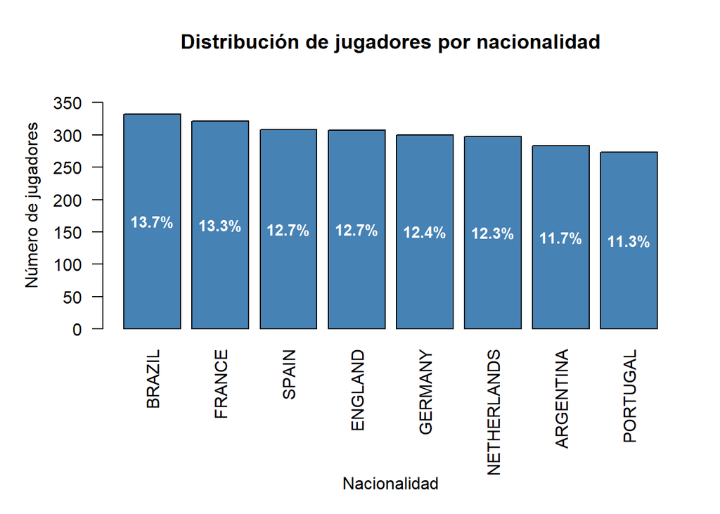

```r
par(mar = c(9, 5, 4, 2))  # abajo, izquierda, arriba, derecha

# Conteo y porcentajes
conteo_nat <- sort(table(datos_limpio_eda$nationality), decreasing = TRUE)
porcentaje <- round(conteo_nat / sum(conteo_nat) * 100, 1)

# Gráfico de barras
barplot_height <- barplot(
  conteo_nat,
  las = 2,
  col = "steelblue",
  main = "Distribución de jugadores por nacionalidad",
  ylab = "Número de jugadores",
  ylim = c(0, max(conteo_nat) * 1.15)
)

mtext(
  "Nacionalidad",
  side = 1,
  line = 7
)

text(
  x = barplot_height,
  y = conteo_nat / 2,
  labels = paste0(porcentaje, "%"),
  col = "white",
  cex = 0.9,
  font = 2
)
```

Verificación cantidades

```r
conteo_nat
```

```
##
##      BRAZIL      FRANCE       SPAIN     ENGLAND     GERMANY NETHERLANDS
##         332         321         308         307         300         297
##   ARGENTINA    PORTUGAL
##         283         273
```

```r
sum(conteo_nat)
```

```
## [1] 2421
```

Cantidad de jugadores por posición

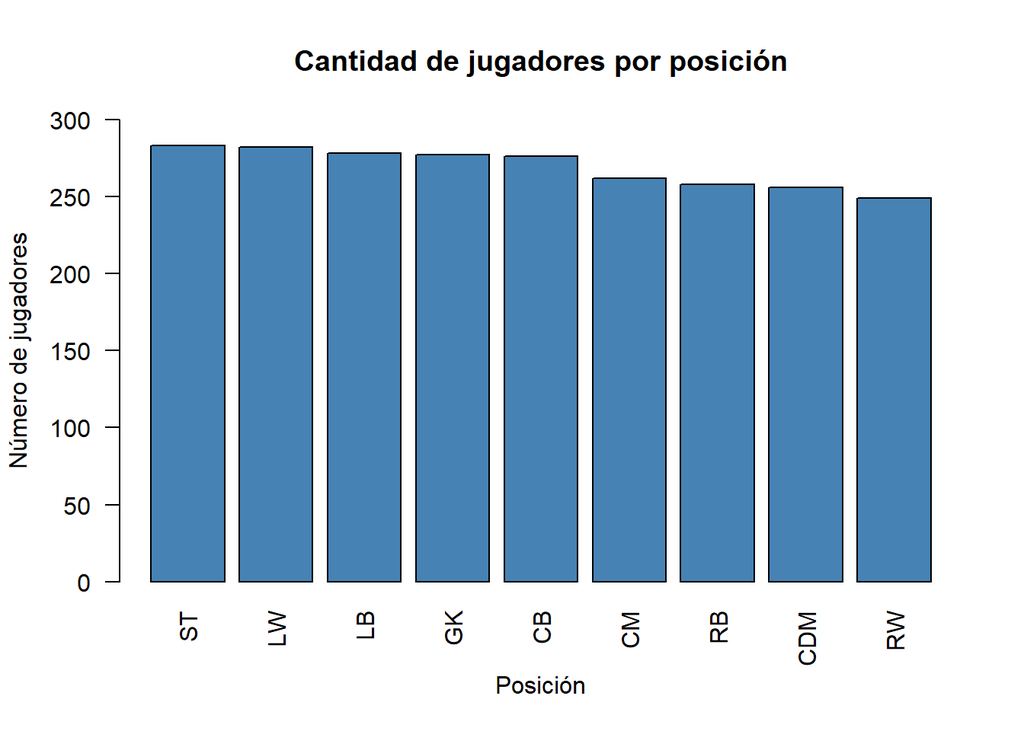

```r
conteo_pos <- sort(table(datos_limpio_eda$position), decreasing = TRUE)

barplot(
  conteo_pos,
  las = 2,
  col = "steelblue",
  main = "Cantidad de jugadores por posición",
  ylab = "Número de jugadores",
  xlab = "Posición",
  ylim = c(0,300)
)
```

Verificación cantidades

```r
max(table(datos_limpio_eda$position))
```

```
## [1] 283
```

```r
min(conteo_pos)
```

```
## [1] 249
```

```r
conteo_pos
```

```
##
##  ST  LW  LB  GK  CB  CM  RB CDM  RW
## 283 282 278 277 276 262 258 256 249
```

Boxplot de Goles (goals) por posición

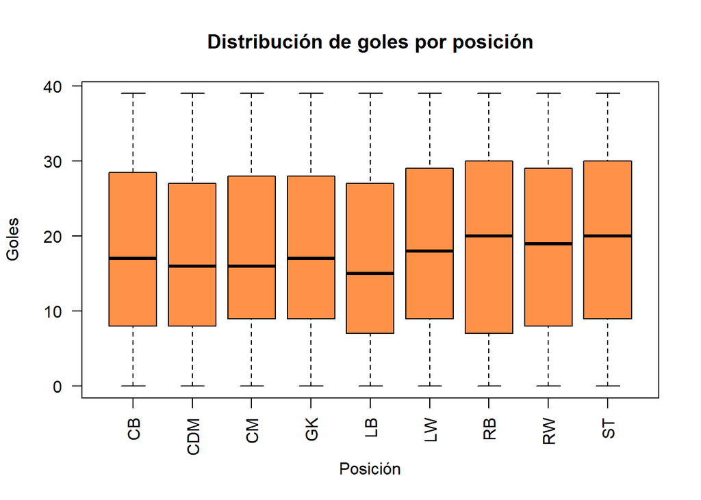

```r
boxplot(
  goals ~ position,
  data = datos_limpio_eda,
  las = 2,
  col = "#FF9149",
  main = "Distribución de goles por posición",
  ylab = "Goles",
  xlab = "Posición"
)
```

Valor de Mercado por Posición

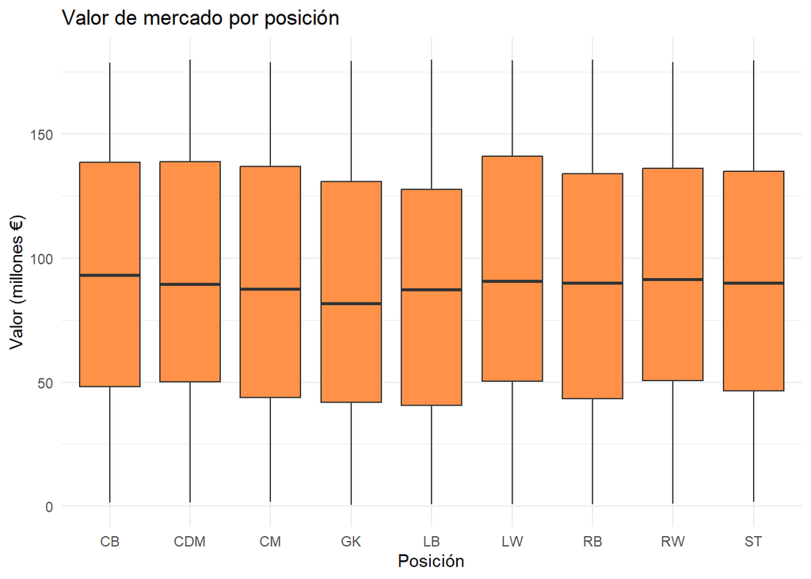

```r
ggplot(datos_limpio_eda, aes(x = position, y = market_value_million_eur)) +
  geom_boxplot(fill = "#FF9149") +
  labs(
    title = "Valor de mercado por posición",
    x = "Posición",
    y = "Valor (millones €)"
  ) +
  theme_minimal()
```

Overal Rating

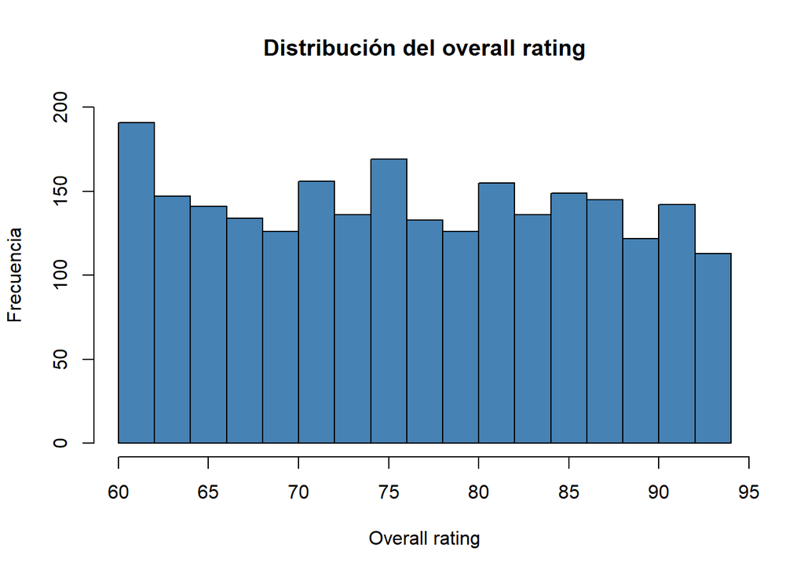

```r
hist(
  datos_limpio_eda$overall_rating,
  col = "steelblue",
  main = "Distribución del overall rating",
  xlab = "Overall rating",
  ylab = "Frecuencia",
  ylim = c(0,200)
)
```

Overal Rating vs Potencial ( Puede mejorar ? )

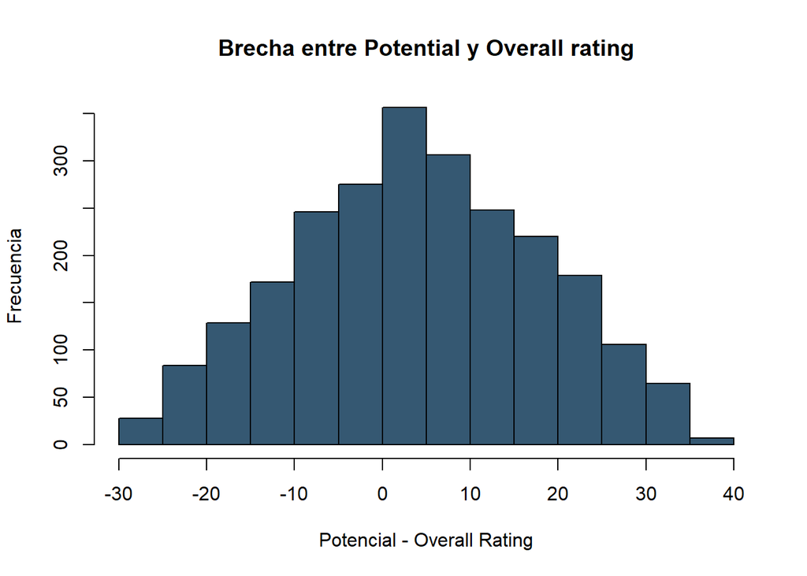

```r
brecha_potencial <- datos_limpio_eda$potential_rating - datos_limpio_eda$overall_rating

hist(
  brecha_potencial,
  breaks = 20,
  col = "#355872",
  main = "Brecha entre Potential y Overall rating",
  xlab = "Potencial - Overall Rating",
  ylab = "Frecuencia"
)
```

```r
id_brecha_max <- which.max(brecha_potencial)
datos_limpio_eda$player_name[id_brecha_max]
```

```
## [1] "Player_375"
```

```r
datos_limpio_eda %>%
  arrange(desc(goals)) %>%
  slice(1:10) %>%
  select(player_name, goals)
```

```
##    player_name goals
## 1    Player_12    39
## 2    Player_19    39
## 3   Player_130    39
## 4   Player_158    39
## 5   Player_168    39
## 6   Player_177    39
## 7   Player_189    39
## 8   Player_233    39
## 9   Player_288    39
## 10  Player_328    39
```

```r
datos_limpio_eda %>%
  mutate(goals_90 = goals / minutes_played * 90) %>%
  arrange(desc(goals_90)) %>%
  slice(1:10) %>%
  select(player_name, goals, minutes_played, goals_90)
```

```
##    player_name goals minutes_played goals_90
## 1   Player_935    37           1005 3.313433
## 2   Player_693    22            599 3.305509
## 3  Player_2255    23            629 3.290938
## 4  Player_2342    38           1042 3.282150
## 5  Player_2234    31            853 3.270809
## 6  Player_1524    19            524 3.263359
## 7   Player_215    12            335 3.223881
## 8   Player_971    28            785 3.210191
## 9  Player_1479    37           1038 3.208092
## 10 Player_2406    17            478 3.200837
```

Distribución según valor de mercado

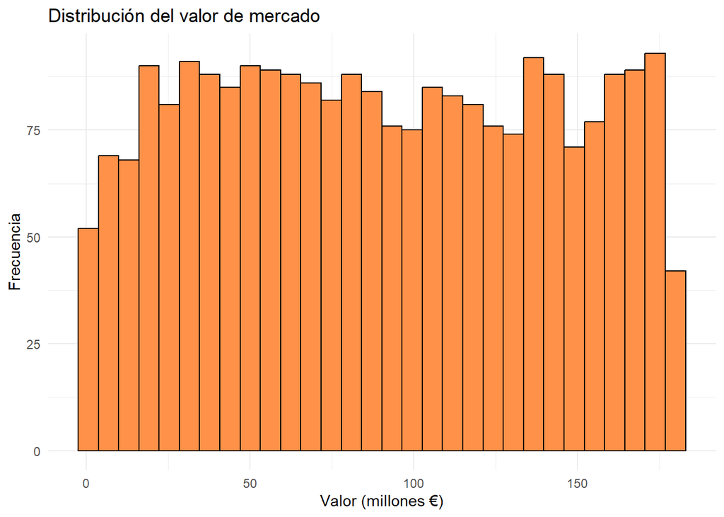

```r
ggplot(datos_limpio_eda, aes(x = market_value_million_eur)) +
  geom_histogram(bins = 30, fill = "#FF9149", color = "black") +
  labs(
    title = "Distribución del valor de mercado",
    x = "Valor (millones €)",
    y = "Frecuencia"
  ) +
  theme_minimal()
```

Distribución de partidos jugados

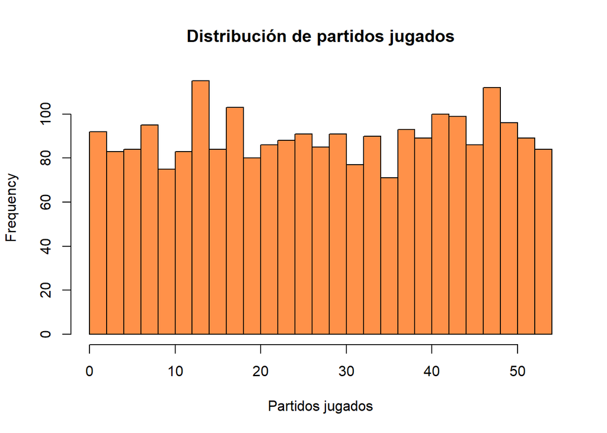

```r
hist(
  datos_limpio_eda$matches_played,
  breaks = 20,
  col = "#FF9149",
  main = "Distribución de partidos jugados",
  xlab = "Partidos jugados"
)
```

Goles vs Asistencias

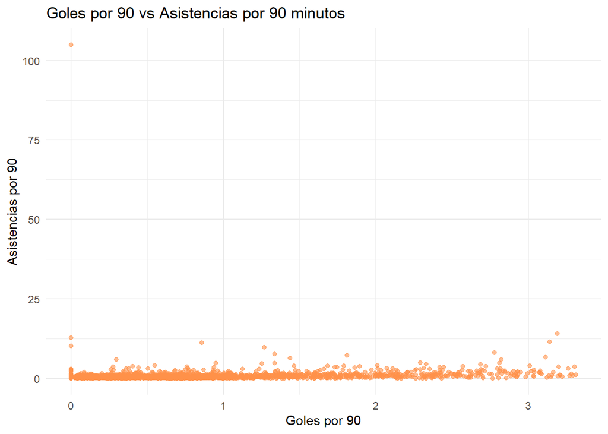

```r
datos_limpio_eda <- datos_limpio_eda %>%
  mutate(
    goals_90 = goals / minutes_played * 90,
    assists_90 = assists / minutes_played * 90
  )


ggplot(datos_limpio_eda, aes(x = goals_90, y = assists_90)) +
  geom_point(alpha = 0.6, color = "#FF9149") +
  labs(
    title = "Goles por 90 vs Asistencias por 90 minutos",
    x = "Goles por 90",
    y = "Asistencias por 90"
  ) +
  theme_minimal()
```

Muestra jugador más destacado segun Goles y Asistencias

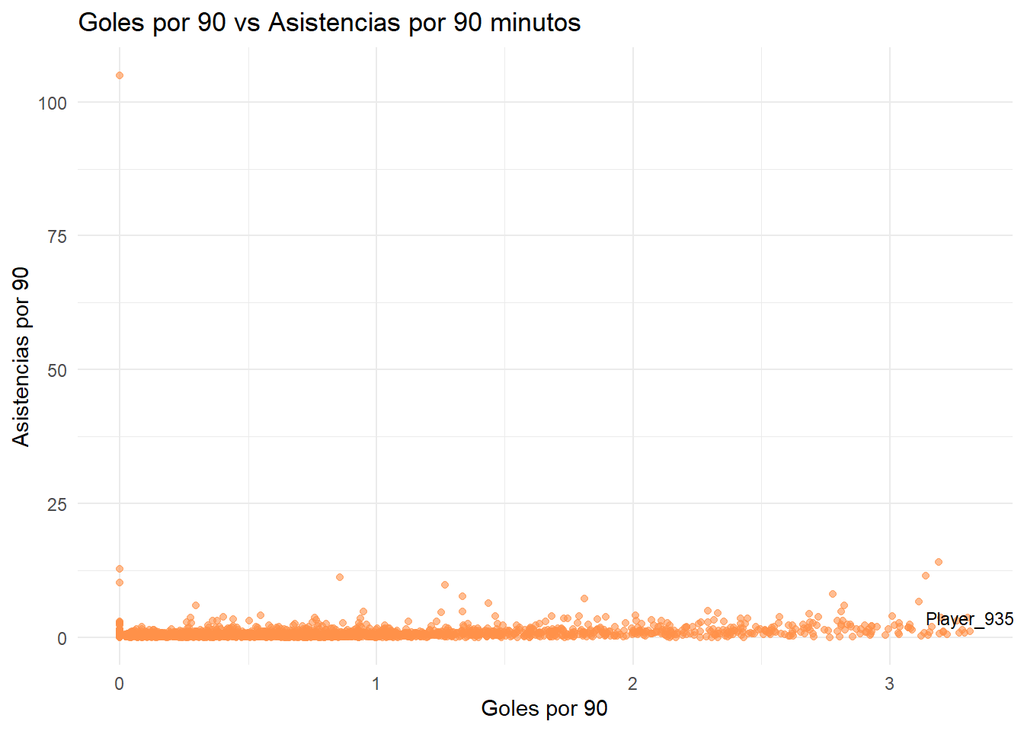

```r
top10_goals90 <- datos_limpio_eda %>%
  mutate(goals_90 = goals / minutes_played * 90,
         assists_90 = assists / minutes_played * 90) %>%
  arrange(desc(goals_90)) %>%
  slice(1:1)

# Gráfico con etiquetas solo para top 10
datos_limpio_eda %>%
  mutate(goals_90 = goals / minutes_played * 90,
         assists_90 = assists / minutes_played * 90) %>%
  ggplot(aes(x = goals_90, y = assists_90)) +
  geom_point(alpha = 0.6, color = "#FF9149") +
  geom_text(
    data = top10_goals90,
    aes(label = player_name),
    vjust = -0.5,
    size = 3,
    color = "black"
  ) +
  labs(
    title = "Goles por 90 vs Asistencias por 90 minutos",
    x = "Goles por 90",
    y = "Asistencias por 90"
  ) +
  theme_minimal()
```

Valor de mercado vs Propenso a lesiones

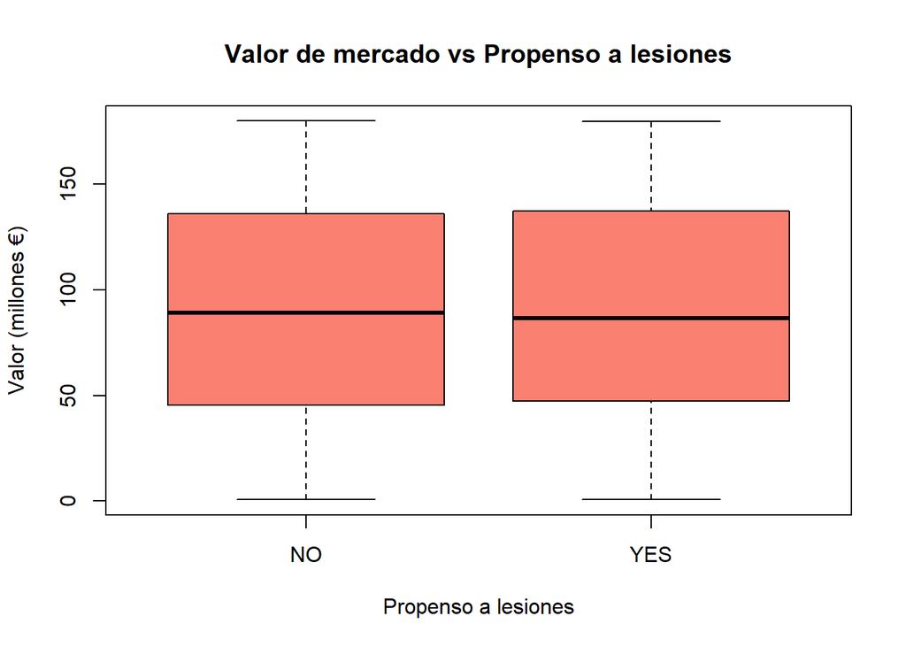

```r
boxplot(
  market_value_million_eur ~ injury_prone,
  data = datos_limpio_eda,
  col = "salmon",
  main = "Valor de mercado vs Propenso a lesiones",
  ylab = "Valor (millones €)",
  xlab = "Propenso a lesiones"
)
```

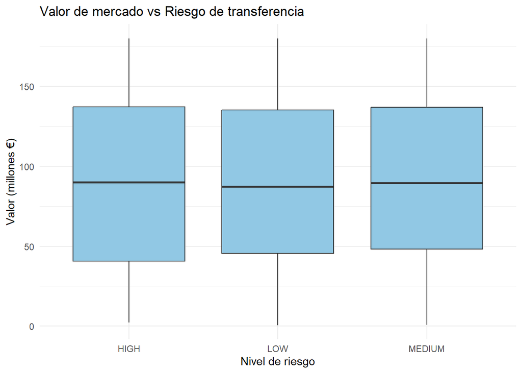

```r
ggplot(datos_limpio_eda, aes(x = transfer_risk_level, y = market_value_million_eur)) +
  geom_boxplot(fill = "#91C8E4") +
  labs(
    title = "Valor de mercado vs Riesgo de transferencia",
    x = "Nivel de riesgo",
    y = "Valor (millones €)"
  ) +
  theme_minimal()
```

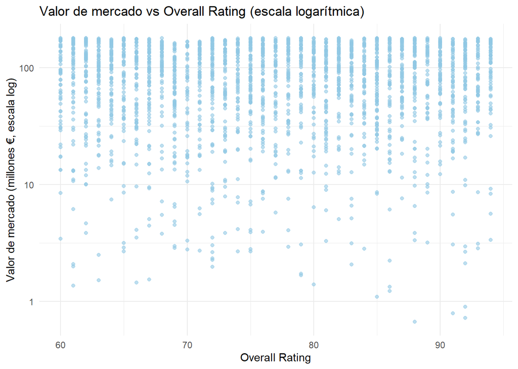

```r
ggplot(datos_limpio_eda,
       aes(x = overall_rating, y = market_value_million_eur)) +
  geom_point(alpha = 0.6, color = "#91C8E4") +
  scale_y_log10() +
  labs(
    title = "Valor de mercado vs Overall Rating (escala logarítmica)",
    x = "Overall Rating",
    y = "Valor de mercado (millones €, escala log)"
  ) +
  theme_minimal()
```

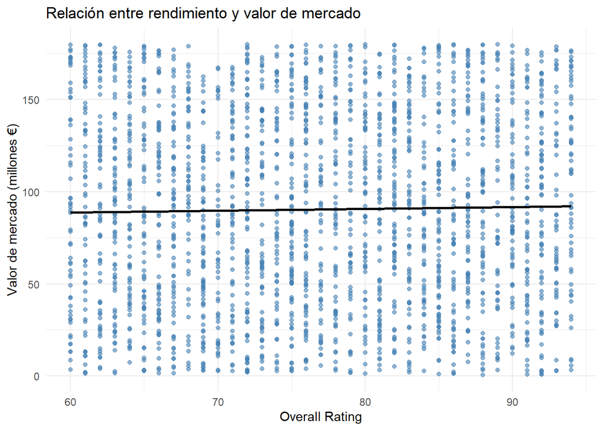

```r
ggplot(datos_limpio_sl,
       aes(x = overall_rating, y = market_value_million_eur)) +
  geom_point(alpha = 0.6, color = "steelblue") +
  geom_smooth(method = "lm", se = FALSE, color = "black") +
  labs(
    title = "Relación entre rendimiento y valor de mercado",
    x = "Overall Rating",
    y = "Valor de mercado (millones €)"
  ) +
  theme_minimal()
```

# CLUSTERIZACIÓN

Columnas a Utilizar

Antes de empezar a realizar la clusterización primero debemos de buscar cuales son las columnas con las que vamos a trabajar, esto se realiza por medio del ACP pero primero solamente seleccionaremos las que sean de carácter numérico.

Debido al proceso que se realiza para el ACP debemos de utilizar dichas variables de carácter numérico son las que nos dan el valor que necesitamos para su realización.

Paquetes a Utilizar

```r
suppressWarnings(library(factoextra))
# Filtrar solo columnas numéricas

df_numericos <- datos_limpio_eda %>%
  select(where(is.numeric))

# APLICAR ACP, scale. = TRUE es fundamental para normalizar los datos
pca_resultado <- prcomp(df_numericos, center = TRUE, scale. = TRUE)

# Visualizar resultados
summary(pca_resultado)
```

```
## Importance of components:
##                           PC1    PC2    PC3     PC4     PC5     PC6     PC7
## Standard deviation     1.4246 1.3391 1.1550 1.02849 1.02417 1.00718 0.99236
## Proportion of Variance 0.1691 0.1494 0.1112 0.08815 0.08741 0.08453 0.08206
## Cumulative Proportion  0.1691 0.3185 0.4297 0.51786 0.60527 0.68981 0.77187
##                            PC8     PC9    PC10    PC11      PC12
## Standard deviation     0.97960 0.96208 0.85189 0.35583 1.394e-15
## Proportion of Variance 0.07997 0.07713 0.06048 0.01055 0.000e+00
## Cumulative Proportion  0.85184 0.92897 0.98945 1.00000 1.000e+00
```

```r
# Ver las cargas (loadings) de las variables en los componentes
head(pca_resultado$rotation)
```

```
##                          PC1         PC2         PC3         PC4          PC5
## age               0.03106352 -0.03899133 -0.02344961 -0.12388981  0.646457121
## overall_rating    0.50378702 -0.03368601  0.16115990 -0.21546970 -0.084512070
## potential_rating -0.49625845 -0.04656667  0.12446049 -0.24720093 -0.033631811
## matches_played    0.01310987  0.02728522  0.12595819 -0.06475844 -0.104084067
## goals             0.02205375 -0.39989687 -0.61788828  0.21563341 -0.007867644
## assists          -0.03336172 -0.09772399  0.23748167  0.77543792  0.199182996
##                          PC6         PC7         PC8        PC9        PC10
## age              -0.28362307  0.05879752  0.62111924 -0.2880041 -0.10495462
## overall_rating   -0.23659367  0.07678361 -0.31708104 -0.5001232  0.03759228
## potential_rating -0.27606657  0.11973383 -0.34013396 -0.4727969  0.02458824
## matches_played   -0.76701612 -0.46828417 -0.01711425  0.4001645  0.01224183
## goals            -0.12011262 -0.12794035 -0.15222755 -0.1291132 -0.26541267
## assists          -0.08276986 -0.11792575 -0.09024709 -0.2046350  0.47028004
##                          PC11          PC12
## age               0.007695574 -3.572897e-17
## overall_rating   -0.001274814  5.015687e-01
## potential_rating -0.003599586 -4.933911e-01
## matches_played    0.003588180  6.938894e-17
## goals             0.519776324  4.857226e-17
## assists           0.004579076 -1.110223e-16
```

Una vez terminado el proceso vamos a visualizar información de utilidad como la desviación estándar que es con lo cual se realiza la división a la hora de realizar el ACP o la proporción de varianza la cual nos dice que cuantos datos de originales llegó a capturar.

Ahora que tenemos realizado el PCA queremos ver de manera visual los elementos con los cuales podemos trabajar por lo cual gracias a la librería “factoextra” podemos mostrarlo de una manera mas clara.

[figure not shown]

```r
# 1. Gráfico de individuos (puntos)
fviz_pca_ind(pca_resultado,
             col.ind = "cos2", # Color por calidad de representación
             gradient.cols = c("#1B3C53", "#91C8E4", "#FC4E07"),
             repel = TRUE)     # Evita que el texto se amontone
```

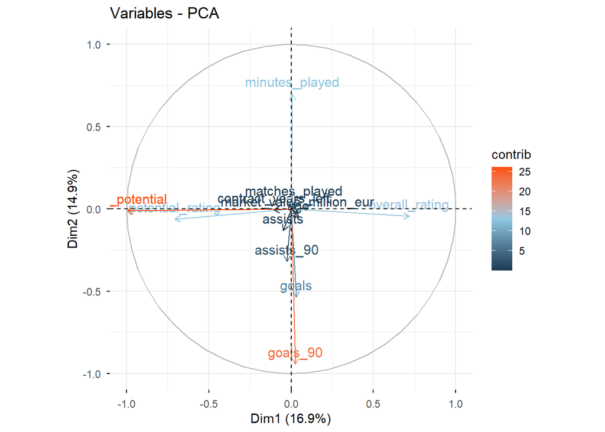

```r
# 2. Gráfico de variables (flechas)
fviz_pca_var(pca_resultado,
             col.var = "contrib", # Color por cuánto contribuyen al componente
             gradient.cols = c("#1B3C53", "#91C8E4", "#FC4E07"))
```

Clusterización

La clusterización consiste en la agrupación de un conjunto de datos en un grupo llamado “cluster”. La idea es que los elementos que tienen similitudes entre sí se agrupen entre ellos y se generen distancias entre elementos con los que no tengan tanta similitud.

El objetivo principal es encontrar patrones que no sean sencillos de detectar a simple vista.

El primer paso es la selección de variables, para óptimos resultados seleccionamos solamente variables numéricas. Se han seleccionado las siguientes columnas: “age”, “overall_rating”, “potential_rating”, “goals”, “market_value_million_eur”.

```r
subconjunto <- datos[, c("age", "overall_rating", "potential_rating",
                         "goals", "market_value_million_eur")]
```

Una vez seleccionadas las variables que vamos a usar, se deben “escalar”, este proceso consiste en transformar las variables numéricas para que todas tengan un rango/escala similar, de forma que se garantiza una correcta formación de grupos.

```r
datos_listos <- scale(subconjunto)
```

Para la realización de un Clustering Jerárquico se requiere tomar en cuenta varios pasos.

Inicialmente, se calcula una matriz de distancias, midiendo la distancia “Euclídea” (la cual mide una línea recta entre cada par de jugadores basándose en sus estadísticas). El objetivo de este paso es identificar los jugadores que tienen distancias cercanas al cero para conocer quiénes están más cerca.

```r
distancias <- dist(datos_listos, method = "euclidean")
```

Una vez que se calculan las distancias, se emplea un algoritmo de agrupamiento llamado “ward.D2”, el cual se encarga de compactar a los grupos para que la varianza interna sea mínima.

```r
hc_final <- hclust(distancias, method = "ward.D2")
```

Para determinar la cantidad óptima de Clusters se puede elaborar una prueba llamada “Codo de Jambu”, el cual consiste en un gráfico que valora un rango de valores de Clusters (en este caso de 1 a 20 Clusters), en el cual hay que poner atención al punto donde se genera un “codo” y seguidamente se estabiliza la línea.

La “altura” representa qué tan diferentes eran los grupos antes de unirse, por lo que al graficarlas de mayor a menor buscamos donde se genera el punto de quiebre.

En este caso específico se presentan varios codos (en los puntos 2, 5 y 8) pero como la “inercia” sigue bajando después de ellos, estos quedan descartados, dado que se observa un último codo y con mayor estabilidad en el punto 15.

En síntesis, según este Codo de Jambu, se tienen que usar 15 Clusteres.

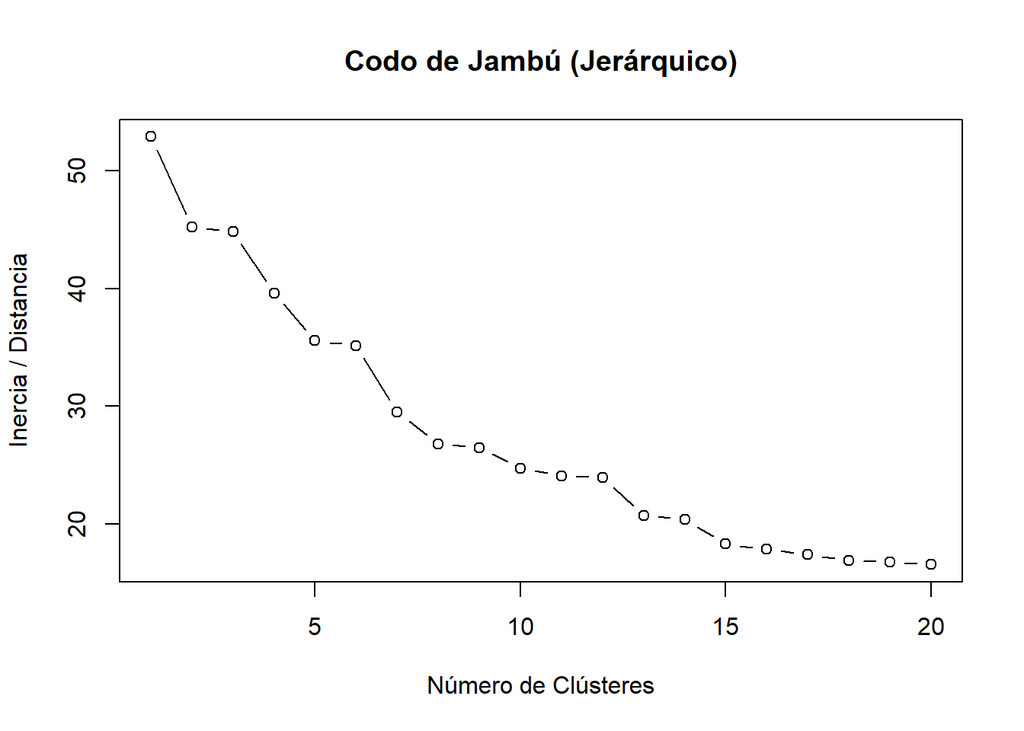

```r
alturas <- sort(hc_final$height, decreasing = TRUE)
plot(alturas[1:20], type = "b", main = "Codo de Jambú (Jerárquico)",
     xlab = "Número de Clústeres", ylab = "Inercia / Distancia")
```

Posteriormente, se procede a realizar el Dendograma para visualizar dónde es que los grupos se dividen.

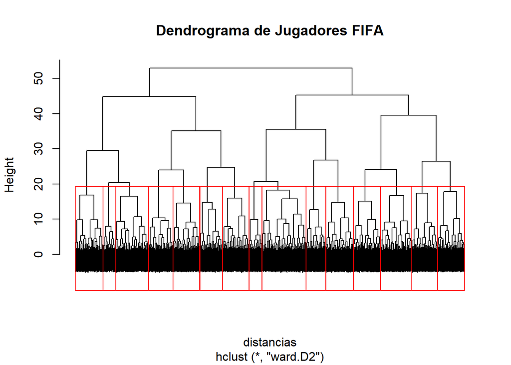

```r
# Dibujar el Dendrograma
plot(hc_final, main = "Dendrograma de Jugadores FIFA", labels = FALSE)

# Supongamos que el "Codo" nos sugirió 3 grupos:
rect.hclust(hc_final, k = 15, border = "red") # Dibuja los rectángulos de corte
```

```r
# Creamos la variable que dice a qué grupo pertenece cada jugador
grupos <- cutree(hc_final, k = 15)

# Añadimos los grupos al dataset original para analizarlos
datos$cluster <- as.factor(grupos)
```

Gracias a la clusterización se pueden hacer hallazgos interesantes, como los siguientes:

En el Cluster número 1 podemos encontrar jugadores que tienen un Valor de Mercado promedio (market_value_million_eur) de 133.19 millones de euros, pero que tienen una valoración general (overall_rating) promedio de 65.37; es decir, que son jugadores cuyos precios son bastante altos pero que su rendimiento es regular, por lo que no sería idónea su contratación.

```r
jugadores_cluster_1 <- datos[datos$cluster == 1, c("player_name", "overall_rating", "market_value_million_eur")]
head(jugadores_cluster_1, 10)
```

```
##     player_name overall_rating market_value_million_eur
## 1      Player_1             65                   122.51
## 13    Player_13             62                    87.53
## 42    Player_42             64                   153.09
## 59    Player_59             60                   123.18
## 61    Player_61             62                   179.63
## 63    Player_63             68                   167.74
## 67    Player_67             62                   137.02
## 73    Player_73             61                   159.67
## 160  Player_160             64                   118.94
## 183  Player_183             71                   130.32
```

```r
summary(jugadores_cluster_1)
```

```
##  player_name        overall_rating  market_value_million_eur
##  Length:163         Min.   :60.00   Min.   : 47.74
##  Class :character   1st Qu.:62.00   1st Qu.:110.34
##  Mode  :character   Median :65.00   Median :137.02
##                     Mean   :65.37   Mean   :133.19
##                     3rd Qu.:68.00   3rd Qu.:159.53
##                     Max.   :79.00   Max.   :179.63
```

En el Cluster número 9, el cual era el más grande del Dendograma, encontramos jugadores que tienen un Valor de Mercado promedio (market_value_million_eur) de 40.51 millones de euros, pero que tienen una valoración general (overall_rating) promedio de 78.69; es decir, que son jugadores cuyo precio promedio no es tan alto (lo cual los vuelve accesibles para más clubes) y cuya valoración promedio es bastante buena, factores que vuelven a este grupo de jugadores como una buena contratación.

```r
jugadores_cluster_9 <- datos[datos$cluster == 9, c("player_name", "overall_rating", "market_value_million_eur")]
head(jugadores_cluster_9, 10)
```

```
##     player_name overall_rating market_value_million_eur
## 12    Player_12             72                    89.27
## 17    Player_17             82                    37.30
## 39    Player_39             93                    61.84
## 43    Player_43             93                    58.33
## 53    Player_53             80                    24.83
## 86    Player_86             84                    76.65
## 98    Player_98             79                    13.16
## 99    Player_99             62                    31.35
## 116  Player_116             92                    32.97
## 127  Player_127             73                    19.07
```

```r
summary(jugadores_cluster_9)
```

```
##  player_name        overall_rating  market_value_million_eur
##  Length:194         Min.   :60.00   Min.   :  0.85
##  Class :character   1st Qu.:72.25   1st Qu.: 20.36
##  Mode  :character   Median :78.00   Median : 37.38
##                     Mean   :78.69   Mean   : 40.51
##                     3rd Qu.:85.75   3rd Qu.: 58.47
##                     Max.   :94.00   Max.   :114.07
```